# Density surface modelling

**THIS FILE IS WORK IN PROGRESS**

```r
# install.packages(c("dsm", "Distance", "distill", "rgdal",
#                    "maptools", "plyr", "tweedie"))
#### Load packages
library(tidyverse)
library(readxl)
library(mvtnorm)
# if(!"devtools" %in% rownames(installed.packages()))
#   {install.packages("devtools")}
# devtools::install_github('david-borchers/LT2D')
library(LT2D)
library(dsm)
library(Distance)
library(distill)
library(rgdal)
library(plyr)
library(maptools)
library(tweedie)
```

```r
#### Load 2D distance functions
source("functions/com_hfunctions.R")
source("functions/com_pifunctions.R")
source("functions/com_likelihoodutilities.R")
source("functions/GoFy_vlm.R") # custom GoFy function, modified by VLM 2022-11-11
source("functions/dsm_custom_functions.R")
```

# Data preparation: impala

## Data import

First of all, we need to prepare the data for the following DSM analysis. We need three data.frames:

- **segdata** holds the segment data (transects “chopped” into segments), with all the covariates
- **obsdata** obsdata links the distance data (already used in the previous step of the analysis to fit the detection function) to the segments
- **preddata** holds the prediction grid (which includes all the necessary covariates)

*Please note that when reading the file, we specify the column types: make sure to maintain the recommended order of the columns to avoid errors in the procedure; additional columns could of course be added, or the order changed, but then you will have to modify the `col_types` argument accordingly*

```r
#### Load dataset
segdata <- read_excel(paste("data/",params$segdata_file,sep=""),
                      # orignal file name: impala_segmenti_vlm_NEW.xlsx/imapla_segementi_vlm_NEW.xlsx
                      #"data/impala_segmenti_vlm.xlsx",
                      #sheet="template_dataset",
                      col_types = c(rep("text", 2),
                                    rep("numeric", 3)))
```

```
Avvertimento: Coercing text to numeric in C1109 / R1109C3: '3461809.818'Avvertimento: Coercing text to numeric in D1109 / R1109C4: '-1548902.792'
```

```r
head(segdata)
```

| Transect.Label | Sample.Label | x | y | Effort |
| --- | --- | --- | --- | --- |
| 1 | 1-1 | 3491961 | -1538603 | 400 |
| 1 | 1-2 | 3492228 | -1538308 | 400 |
| 1 | 1-3 | 3492544 | -1538064 | 400 |
| 1 | 1-4 | 3492856 | -1537825 | 400 |
| 1 | 1-5 | 3493240 | -1537797 | 400 |
| 1 | 1-6 | 3493624 | -1537735 | 400 |

and additional, optional columns can be added, to describe the segments in terms of environmental covariates (e.g., information on habitats, distance from water sources or from anthropic areas such as villages, altitude, …). All optional fields can have empty cells (or *NA*) in the Excel file (although this will affect their use in the following modelling procedures). On the contrary, *NA*s are not admitted in the fields: `area`, `Transect.Label`, `Sample.Label`, `x`, `y`, `Effort`.

```r
obsdata <- read_excel(paste("data/",params$obsdata_file,sep=""),
                      #sheet="template_dataset",
                      col_types = c("numeric",
                                    "text",
                                    rep("numeric", 3)))
head(obsdata)
```

| object | Sample.Label | x | y | Effort |
| --- | --- | --- | --- | --- |
| 1 | 1-37 | 335402.9 | 8489993 | 400 |
| 5 | 5-5 | 316847.0 | 8482050 | 400 |
| 6 | 5-37 | 308669.8 | 8479058 | 400 |
| 8 | 7-13 | 293692.9 | 8478885 | 400 |
| 9 | 7-15 | 293259.1 | 8478616 | 400 |
| 10 | 7-17 | 293178.0 | 8479295 | 400 |

The `obsdata` dataset (Excel file) should include the following columns (order matters):

- `object`: a progressive number to identify each record (*i.e.*, 1,2,3,4,…) - this field connects the `obsdata` table to the data used in the previous analysis to fit the detection function (`data_trunc_SPECIES NAME`)
- `Sample.Label`: label that identifies the segment within a transect, it is composed by the transect label (`Transect.Label`), a separator (e.g., -), and a unique identifier of the segment within the transect - this field connects the `obsdata` table to the `segdata` table
- `x`: x-coord of the group of animals (optional)
- `y`: y-coord of the group of animals (optional)
- `Effort`: length of the segment, in m (optional) The `x` and `y` fields can have empty cells (or *NA*) in the Excel file. On the contrary, *NA*s are not admitted in the fields: `object`, `Sample.Label`, `Effort`.

For the observations, we have to consider the ones already used in the previous step of the analysis to fit the detection function. Thus, we load the corresponding *.RData* file and we link the two datasets (`obsdata` and `trunc_data`) using the `object` field to obtain the final `obsdata` object.

```r
# please note that data_trunc comes from the previous 2D distance sampling analysis
load(paste("output/data_trunc_",params$species_name,".RData",sep = ""))
left_join(obsdata, data_trunc, by = "object") %>%
  dplyr::select(object:Effort, cluster_size, perp_dist) %>%
  dplyr::rename(size = cluster_size, distance = perp_dist) -> obsdata

# include a column to identify the detection function object: here, we only have one detection function
# so the ddfobj colum has a fixed value of 1 and it is added to both the segments and the observation datasets
obsdata %>%
  mutate(ddfobj = 1) -> obsdata
segdata %>%
  mutate(ddfobj = 1) -> segdata

head(obsdata)
```

| object | Sample.Label | x | y | Effort | size | distance | ddfobj |
| --- | --- | --- | --- | --- | --- | --- | --- |
| 1 | 1-37 | 335402.9 | 8489993 | 400 | 2 | 55 | 1 |
| 5 | 5-5 | 316847.0 | 8482050 | 400 | 8 | 27 | 1 |
| 6 | 5-37 | 308669.8 | 8479058 | 400 | 1 | 69 | 1 |
| 8 | 7-13 | 293692.9 | 8478885 | 400 | NA | NA | 1 |
| 9 | 7-15 | 293259.1 | 8478616 | 400 | 1 | 148 | 1 |
| 10 | 7-17 | 293178.0 | 8479295 | 400 | 1 | 34 | 1 |

Please note that a column `ddfobj` has been added to identify the detection function used (in this case there is only one so it is a constant). The same column has been added to the `segdata` table as well.

```r
#### Load dataset
preddata <- read_excel(paste("data/", params$preddata_file, sep = ""),
                      col_types = rep("numeric", 4))
head(preddata)
```

| id | x | y | area |
| --- | --- | --- | --- |
| 683 | 3456516 | -1555820 | 160000 |
| 682 | 3456480 | -1555400 | 160000 |
| 681 | 3456496 | -1555035 | 160000 |
| 680 | 3456533 | -1554589 | 160000 |
| 679 | 3456473 | -1554208 | 160000 |
| 678 | 3456472 | -1553809 | 160000 |

Finally, the `preddata` dataset (Excel file) should include at least the following columns: - `id`: a unique identifier for each grid cell in the study area - `x`: x-coord of the center of the cell - `y`: y-coord of the center of the cell - `area`: the area of each cell (in m$^2$) Please pay attention to the coordinates of the cells, that should be in the same reference system used for the other datasets, in particular the `segdata`. Additional columns including the values for environmental covariates can also be included.

## Detection function

To reconstruct the detection function for the following DSM, we consider the detection function object obtained in the previous phase and we derive a table with the estimated detection probability for each observation:

```r
load(paste("output/fitVU_", params$species_name, ".RData", sep = ""))

est = fitVU

Nhat.yx=bias=NULL
b=est$b; hr=match.fun(est$hr); ystart=est$ystart; pi.x=match.fun(est$pi.x)
logphi=est$logphi; w=est$w
x = obsdata$distance
f.x=p.x.std=adbnTRUE=0
arrange(obsdata, distance) %>%
  dplyr::select(object, distance) %>%
  na.omit() -> gridx.df

p.xpifit=p.pi.x(gridx.df$distance,b,hr,ystart,pi.x,logphi,w)
mufit=integrate(f=p.pi.x,lower=0,upper=w,b=b,hr=hr
                  ,ystart=ystart,pi.x=pi.x,logphi=logphi,w=w)$value # phat media dei gruppi
f.xfit=p.xpifit/mufit
p.xfit=px(gridx.df$distance,b,hr,ystart,nint=nint)
ptot=integrate(f=px,lower=0,upper=w,b=b,hr=hr,ystart=ystart)$value
p.xfit.std=p.xfit/ptot
adbn=pi.x(gridx.df$distance,logphi,w)

bind_cols(p=p.xfit.std, gridx.df) -> fitted.p.df
bind_cols(p=p.xfit, gridx.df) -> fitted.p.df
fitted.p.df
```

| p | object | distance |
| --- | --- | --- |
| 1.0000000 | 42 | 1 |
| 1.0000000 | 91 | 1 |
| 0.9999980 | 51 | 4 |
| 0.9993942 | 31 | 7 |
| 0.9993942 | 53 | 7 |
| 0.9903011 | 73 | 11 |
| 0.9795199 | 37 | 13 |
| 0.9645605 | 75 | 15 |
| 0.9249213 | 74 | 19 |
| 0.9135710 | 12 | 20 |

[output cut: 45 more lines]

Moreover, we need to store the information on detection probabilities in a *fake* detection function object, that will be called by the DSM functions later on.

```r
# if we didn't use ds()...
# probs <- hr.model$ddf$fitted
# object.ids <- names(hr.model$ddf$fitted)

probs <- fitted.p.df$p
object.ids <- fitted.p.df$object

fake.ddf <- list()
fake.ddf$meta.data <- list()
# fake.ddf$meta.data$width <- max(mexdolphins$distdata$distance)
fake.ddf$meta.data$width <- max(fitted.p.df$distance)
fake.ddf$meta.data$left <- 0
fake.ddf$fitted <- probs
names(fake.ddf$fitted) <- object.ids
fake.ddf
```

```
$meta.data
$meta.data$width
[1] 199

$meta.data$left
[1] 0


$fitted
       42        91        51        31        53        73
1.0000000 1.0000000 0.9999980 0.9993942 0.9993942 0.9903011
       37        75        74        12        44        57
0.9795199 0.9645605 0.9249213 0.9135710 0.9135710 0.8897770
       77        49         5        16        10        55
0.8524305 0.8397741 0.8270910 0.7644129 0.7401145 0.7281931
       40        54        95        43        81        39
0.7048530 0.7048530 0.7048530 0.6822252 0.6496834 0.6392160
       72        21        85         1        97        20
0.6089533 0.5897158 0.5447827 0.5280173 0.5198815 0.5119061
       18        84        27         6        11        67
0.4535041 0.4535041 0.4402908 0.4275852 0.4036078 0.3978967
       28        56        76        17        71        29
0.3922940 0.3922940 0.3709174 0.3417103 0.3417103 0.3326705
       38        30        41        78        79        46
0.2957886 0.2847409 0.2776882 0.2610752 0.2487548 0.2290529
       80        47        36        83         9        25
0.1935448 0.1814757 0.1776862 0.1758328 0.1635864 0.1466396
       52
0.1022483
```

# Model fitting

In order to fit the DSMs, first of all we prepare all the above mentioned data using a customized `make.data` function

```r
dat <- make.data_vlm(response = "abundance.est", ddfobject = fitVU,
                     segdata, obsdata, group = FALSE,
                     convert.units = params$convertion_km_m,
                     availability = 1,
                     segment.area = segdata$Effort*max(fitted.p.df$distance)*2,
                     family = tw())
dat
```

| Sample.Label | Transect.Label | x | y | Effort | ddfobj | segment.area | width | abundance.est | off.set |
| --- | --- | --- | --- | --- | --- | --- | --- | --- | --- |
| 1-1 | 1 | 3491961 | -1538603 | 400 | 1 | 159.20 | 199 | 0.000000000 | 5.070161 |
| 1-10 | 1 | 3495118 | -1537280 | 400 | 1 | 159.20 | 199 | 0.000000000 | 5.070161 |
| 1-11 | 1 | 3495437 | -1537080 | 400 | 1 | 159.20 | 199 | 0.000000000 | 5.070161 |
| 1-12 | 1 | 3495610 | -1536724 | 400 | 1 | 159.20 | 199 | 0.000000000 | 5.070161 |
| 1-13 | 1 | 3495790 | -1536385 | 400 | 1 | 159.20 | 199 | 0.000000000 | 5.070161 |
| 1-14 | 1 | 3496097 | -1536555 | 400 | 1 | 159.20 | 199 | 0.000000000 | 5.070161 |
| 1-15 | 1 | 3496424 | -1536781 | 400 | 1 | 159.20 | 199 | 0.000000000 | 5.070161 |
| 1-16 | 1 | 3496774 | -1536966 | 400 | 1 | 159.20 | 199 | 0.000000000 | 5.070161 |
| 1-17 | 1 | 3497156 | -1537079 | 400 | 1 | 159.20 | 199 | 0.000000000 | 5.070161 |
| 1-18 | 1 | 3497539 | -1537149 | 400 | 1 | 159.20 | 199 | 0.000000000 | 5.070161 |

[output cut: 990 more lines]

We can now fit the `dsm` to these data:

```r
mod1<-dsm_vale(abundance.est ~ s(x,y), fake.ddf,
               segment.data, observation.data, dat = dat,
               convert.units = params$convertion_km_m, group = FALSE)
summary(mod1)
```

```
Family: quasipoisson
Link function: log

Formula:
abundance.est ~ s(x, y) + offset(off.set)

Parametric coefficients:
            Estimate Std. Error t value Pr(>|t|)
(Intercept)  -13.657      1.382  -9.884   <2e-16 ***
---
Signif. codes:  0 ‘***’ 0.001 ‘**’ 0.01 ‘*’ 0.05 ‘.’ 0.1 ‘ ’ 1

Approximate significance of smooth terms:
         edf Ref.df     F p-value
s(x,y) 23.09   25.2 1.396   0.096 .
---
Signif. codes:  0 ‘***’ 0.001 ‘**’ 0.01 ‘*’ 0.05 ‘.’ 0.1 ‘ ’ 1

R-sq.(adj) =  0.027   Deviance explained = 24.6%
-REML =  -2730  Scale est. = 0.087495  n = 1736
```

# Prediction

To predict the abundance, we apply the model to the grid data, obtaining the overall abundance (number of individuals) and visualizing the smooth of the spatial coordinates:

```r
# predict over a grid
mod1.pred <- predict(mod1, preddata, preddata$area)
# calculate the predicted abundance over the grid
print("Predicted abundance (no. individuals) over the grid:")
```

```
[1] "Predicted abundance (no. individuals) over the grid:"
```

```r
sum(mod1.pred)
```

```
[1] 7835.182
```

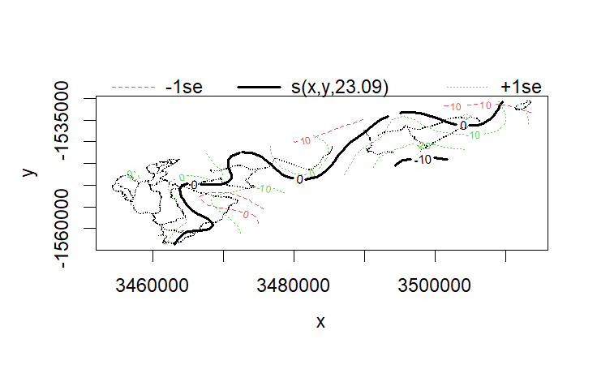

```r
# plot the smooth
plot(mod1)
```

We now estimate the variance for the model:

```r
## --- Variance estimation for the chosen model ----
preddata.varprop.subset <- split(preddata, 1:nrow(preddata))
offset.varprop.subset <- as.list(rep(preddata$area[1],nrow(preddata)))
dsm.var.subset <- dsm_var_gam(dsm.obj=mod1, pred.data=preddata.varprop.subset,
                              off.set = offset.varprop.subset, #seglen.varname = "Effort",
                              type.pred = "response")
# summary(dsm.var.subset)
summary.dsm.var_vale(object = dsm.var.subset, detfunc = fitVU)
```

```
Summary of uncertainty in a density surface model calculated
 analytically for GAM, with delta method

Approximate asymptotic confidence interval:
     2.5%      Mean     97.5%
 2680.114  7835.182 22905.768
(Using log-Normal approximation)

Point estimate                 : 7835.182
CV of detection function       : 0.188585
CV from GAM                    : 0.5274
Total standard error           : 4630.665
Total coefficient of variation : 0.591
```

## Maps of abundance and uncertainty

Finally, we can plot the results to show the abundances within the study area, and the corresponding uncertainty map

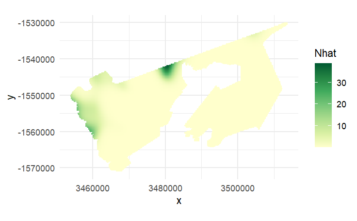

```r
## ---- prediction and plot Nhat and uncertainty ----
prediction.Nhat <- unlist(dsm.var.subset$pred)
prediction.CV <- sqrt(dsm.var.subset$pred.var)/unlist(dsm.var.subset$pred)
prediction.stdev <- sqrt(dsm.var.subset$pred.var)
pp <- mutate(as.data.frame(preddata), Nhat = prediction.Nhat)
pp.uncertainty <- mutate(pp, CV = prediction.CV, stdev = prediction.stdev)
# plot Nhat
pNhat <- ggplot(pp) +
  geom_tile(aes(x=x, y=y, fill=Nhat, width=400, height=400)) +
  scale_fill_distiller(palette = "YlGn", direction=2) +
  #                      values = c(seq(0, 60, 60))) +
  # scale_fill_distiller(palette = "YlGn", direction=2, trans = "log10",
  #                      name = "log10(Similarity)") +
  labs(fill="Nhat") +
  theme_minimal() +
  coord_equal()
print(pNhat)
```

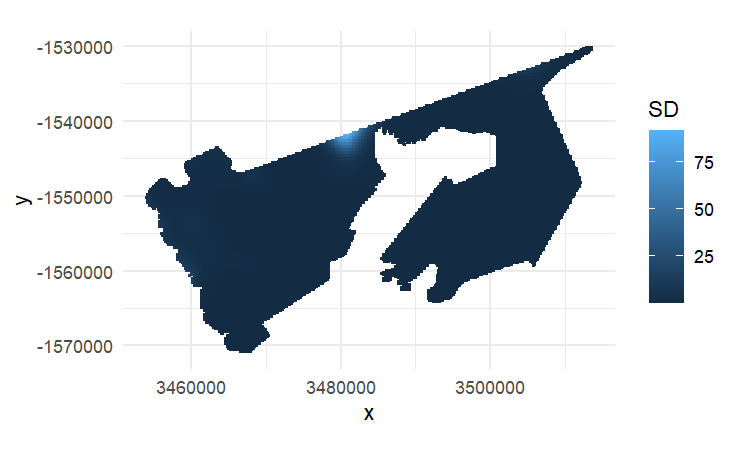

```r
# plot SD
pSD <- ggplot(pp) +
  geom_tile(aes(x=x, y=y, fill=prediction.stdev, width=400, height=400)) +
  labs(fill="SD") +
  theme_minimal() +
  coord_equal()
print(pSD)
```

```r
# pDens <- ggplot(pp) +
#   geom_tile(aes(x=x, y=y, fill=Nhat/0.160000, width=400, height=400)) +
#   scale_fill_distiller(palette = "YlGn", direction=2) +
#   #                      values = c(seq(0, 60, 60))) +
#   # scale_fill_distiller(palette = "YlGn", direction=2, trans = "log10",
#   #                      name = "log10(Similarity)") +
#   labs(fill="density") +
#   theme_minimal() +
#   coord_equal()
# print(pDens)


## ---- save abundance map for GIS ----
write.csv(pp,paste("output/DSMresults_", params$species_name,
                   ".csv", sep = ""))

# pp.uncertainty <- read.csv(paste("output/DSMresults_",
#                                  params$species_name,
#                                  ".csv", sep = ""))
# sum(pp.uncertainty$Nhat)
```